# Chulwalhar Flower Exports: Time Series Data Modeling and Forecasting

## Kappa calculation with 2 indicators

```r
allkappa <- foreach (y = indicators[1:13], .combine = c)  %do% {
  foreach( z = indicators[1:13], .combine =c) %do% {
    kappa(model.matrix(~ y + z))
  }
}

kappasFor2CombinedIndicators <- cbind(allkappa,newnames2)
```

```r
kappasFor2CombinedIndicators[with(kappasFor2CombinedIndicators, order(allkappa)),]
```

[output not shown]

## Kappa calculation with 3 indicators

```r
allkappa <- foreach(x = indicators[1:13], .combine = c) %do% {foreach(y = indicators[1:13], .combine = c)  %do% {
  foreach( z = indicators[1:13], .combine =c) %do% {
    kappa(model.matrix(~ x + y + z))
  }
}
}

kappasFor3CombinedIndicators <- cbind(allkappa,newnames3)
```

```r
kappasFor3CombinedIndicators[with(kappasFor3CombinedIndicators, order(allkappa)),]
```

[output not shown]

## New model

```r
# As trend and seasonality have been shown to forecast well on their own, we will add the new combination to trend and
# seasonality in order to try to improve the forecast.

# 1. Inflation and NationalHolidays additional
# 2. Seasonality and Trend only


# 1. Inflation and NationalHolidays
summary(ModelWithInflationAndNationalHolidays)
```

```
##
## Call:
## tslm(formula = TotalAsIs ~ trend + season + Inflation + NationalHolidays)
##
## Residuals:
##     Min      1Q  Median      3Q     Max
## -547330 -134116   -1286  160632  400324
##
## Coefficients:
##                  Estimate Std. Error t value Pr(>|t|)
## (Intercept)       2151025     125478  17.143  < 2e-16 ***
## trend               26408       1440  18.335  < 2e-16 ***
## season2           -131665     144575  -0.911  0.36629
## season3            190717     153363   1.244  0.21875
## season4           -316061     177379  -1.782  0.08010 .
## season5           -622852     144685  -4.305 6.65e-05 ***
## season6           -882689     144746  -6.098 9.93e-08 ***
## season7          -1078593     144826  -7.447 5.71e-10 ***
## season8           -724466     144917  -4.999 5.82e-06 ***
## season9            706671     145034   4.872 9.16e-06 ***
## season10           302312     145206   2.082  0.04185 *
## season11           475472     145412   3.270  0.00183 **
## season12           514655     212001   2.428  0.01838 *
## Inflation           19310      35331   0.547  0.58681
## NationalHolidays  -436533     153607  -2.842  0.00621 **
## ---
## Signif. codes:  0 '***' 0.001 '**' 0.01 '*' 0.05 '.' 0.1 ' ' 1
##
## Residual standard error: 250400 on 57 degrees of freedom
## Multiple R-squared:  0.9277, Adjusted R-squared:  0.9099
## F-statistic: 52.24 on 14 and 57 DF,  p-value: < 2.2e-16
```

```r
# Adjusted R²: 0.9099

# 2. Seasonality and Trend only (as comparison to 1.)
summary(ModelWithTrendAndSeasonalityOnly)
```

```
##
## Call:
## tslm(formula = TotalAsIs ~ trend + season)
##
## Residuals:
##     Min      1Q  Median      3Q     Max
## -699390 -154210   17753  150363  495430
##
## Coefficients:
##             Estimate Std. Error t value Pr(>|t|)
## (Intercept)  2182435     117276  18.609  < 2e-16 ***
## trend          26427       1514  17.456  < 2e-16 ***
## season2      -131168     152001  -0.863 0.391663
## season3        46585     152024   0.306 0.760356
## season4      -609102     152062  -4.006 0.000176 ***
## season5      -623539     152114  -4.099 0.000129 ***
## season6      -883072     152182  -5.803 2.74e-07 ***
## season7     -1079124     152265  -7.087 1.93e-09 ***
## season8      -724693     152363  -4.756 1.31e-05 ***
## season9       705716     152476   4.628 2.07e-05 ***
## season10      300019     152603   1.966 0.054009 .
## season11      472099     152746   3.091 0.003045 **
## season12       73925     152903   0.483 0.630546
## ---
## Signif. codes:  0 '***' 0.001 '**' 0.01 '*' 0.05 '.' 0.1 ' ' 1
##
## Residual standard error: 263300 on 59 degrees of freedom
## Multiple R-squared:  0.9173, Adjusted R-squared:  0.9004
## F-statistic: 54.51 on 12 and 59 DF,  p-value: < 2.2e-16
```

```r
# Adjusted R²: 0,9004

# The Adjusted R² for ModelWithTrendAndSeasonalityOnly was 0,9004, hence the value for "Inflation and NationalHolidays",
# is slightly better.
# We will forecast with the model and then compare
# to the AsIs and Plan data for 2013.
```

## Forecasts with the new model

### ModelWithInflationAndNationalHolidays

```r
# Shorten ModelWithInflationAndNationalHolidays by one year in order to be able to produce a forecast for 2013.
summary(ModelWithInflationAndNationalHolidays_2012)
```

```
##
## Call:
## tslm(formula = TotalAsIs_2012 ~ trend + season + Inflation_2012 +
##     NationalHolidays_2012)
##
## Residuals:
##     Min      1Q  Median      3Q     Max
## -526307 -134872   10576  170157  465246
##
## Coefficients:
##                       Estimate Std. Error t value Pr(>|t|)
## (Intercept)            2107558     131001  16.088  < 2e-16 ***
## trend                    25101       1872  13.405  < 2e-16 ***
## season2                 -35384     155200  -0.228 0.820690
## season3                 240411     160008   1.502 0.139956
## season4                -386832     219840  -1.760 0.085271 .
## season5                -489470     155364  -3.150 0.002896 **
## season6                -758907     155483  -4.881 1.37e-05 ***
## season7                -995053     155628  -6.394 8.11e-08 ***
## season8                -616741     155730  -3.960 0.000264 ***
## season9                 702251     155903   4.504 4.69e-05 ***
## season10                332293     156117   2.128 0.038807 *
## season11                514195     156424   3.287 0.001968 **
## season12                430932     250212   1.722 0.091888 .
## Inflation_2012           25935      34970   0.742 0.462167
## NationalHolidays_2012  -314744     194415  -1.619 0.112451
## ---
## Signif. codes:  0 '***' 0.001 '**' 0.01 '*' 0.05 '.' 0.1 ' ' 1
##
## Residual standard error: 245400 on 45 degrees of freedom
## Multiple R-squared:  0.9162, Adjusted R-squared:  0.8902
## F-statistic: 35.15 on 14 and 45 DF,  p-value: < 2.2e-16
```

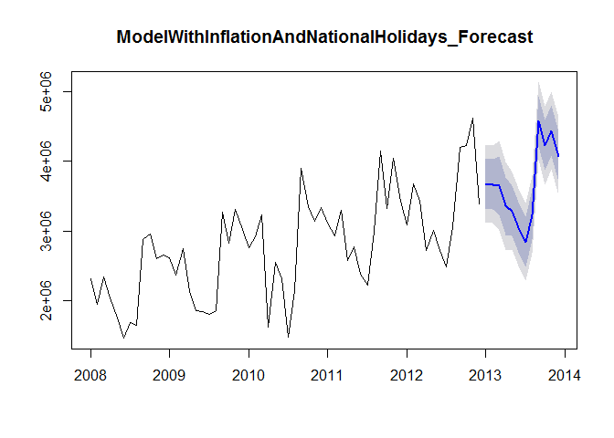

```r
# Add "newdata" to the 2013 indicator values for the forecast
plot(ModelWithInflationAndNationalHolidays_Forecast, main="ModelWithInflationAndNationalHolidays_Forecast")
```

```r
ModelWithInflationAndNationalHolidays_Forecast
```

```
##          Point Forecast   Lo 80   Hi 80   Lo 95   Hi 95
## Jan 2013        3681521 3321098 4041943 3123393 4239648
## Feb 2013        3668645 3308015 4029274 3110197 4227093
## Mar 2013        3651943 3237319 4066568 3009882 4294005
## Apr 2013        3357025 2943712 3770338 2716995 3997056
## May 2013        3289602 2929068 3650137 2731301 3847904
## Jun 2013        3052788 2692425 3413151 2494753 3610823
## Jul 2013        2844077 2483627 3204526 2285907 3402246
## Aug 2013        3237376 2876771 3597981 2678966 3795786
## Sep 2013        4578876 4218123 4939628 4020238 5137513
## Oct 2013        4229091 3867964 4590219 3669872 4788310
## Nov 2013        4438688 4078018 4799359 3880176 4997200
## Dec 2013        4068116 3707678 4428554 3509965 4626268
```

```r
# Correlation of the forecasts and As Is Data. As a comparison, the correlation of the As Is Data for 2013 with the Plan data.
cor(ModelWithInflationAndNationalHolidays_PointForecast, TotalAsIs_2013)
```

```
## [1] 0.9598657
```

```r
cor(TotalAsIs_2013, TotalPlan_2013)
```

```
## [1] 0.929769
```

```r
# A comparison with linear regression also supports the result.
summary(ModelWithInflationAndNationalHolidays_forecast_lm)
```

```
##
## Call:
## lm(formula = TotalAsIs_2013 ~ ModelWithInflationAndNationalHolidays_PointForecast,
##     data = TotalAsIs_2013)
##
## Residuals:
##     Min      1Q  Median      3Q     Max
## -296063 -155536  -40988  109218  411647
##
## Coefficients:
##                                                       Estimate Std. Error
## (Intercept)                                         -1.253e+06  4.703e+05
## ModelWithInflationAndNationalHolidays_PointForecast  1.371e+00  1.267e-01
##                                                     t value Pr(>|t|)
## (Intercept)                                          -2.665   0.0237 *
## ModelWithInflationAndNationalHolidays_PointForecast  10.823 7.67e-07 ***
## ---
## Signif. codes:  0 '***' 0.001 '**' 0.01 '*' 0.05 '.' 0.1 ' ' 1
##
## Residual standard error: 232900 on 10 degrees of freedom
## Multiple R-squared:  0.9213, Adjusted R-squared:  0.9135
## F-statistic: 117.1 on 1 and 10 DF,  p-value: 7.666e-07
```

```r
summary(TotalAsIs_2013_lm)
```

```
##
## Call:
## lm(formula = TotalAsIs_2013 ~ TotalPlan_2013, data = TotalAsIs_2013)
##
## Residuals:
##     Min      1Q  Median      3Q     Max
## -441885 -227385  -43470  184761  466401
##
## Coefficients:
##                  Estimate Std. Error t value Pr(>|t|)
## (Intercept)    -8.972e+04  4.930e+05  -0.182    0.859
## TotalPlan_2013  1.053e+00  1.318e-01   7.987  1.2e-05 ***
## ---
## Signif. codes:  0 '***' 0.001 '**' 0.01 '*' 0.05 '.' 0.1 ' ' 1
##
## Residual standard error: 305700 on 10 degrees of freedom
## Multiple R-squared:  0.8645, Adjusted R-squared:  0.8509
## F-statistic: 63.78 on 1 and 10 DF,  p-value: 1.195e-05
```

### Trend and Seasonality only as benchmark

```r
# Shorten ModelWithTrendAndSeasonalityOnly by one year in order to be able to produce a forecast for 2013.
summary(ModelWithTrendAndSeasonalityOnly_2012)
```

```
##
## Call:
## tslm(formula = TotalAsIs_2012 ~ trend + season)
##
## Residuals:
##     Min      1Q  Median      3Q     Max
## -600304 -116717   -7864  163111  473692
##
## Coefficients:
##             Estimate Std. Error t value Pr(>|t|)
## (Intercept)  2147793     120530  17.820  < 2e-16 ***
## trend          25212       1887  13.363  < 2e-16 ***
## season2       -34146     156872  -0.218 0.828632
## season3       180612     156906   1.151 0.255518
## season4      -639529     156962  -4.074 0.000176 ***
## season5      -490327     157042  -3.122 0.003068 **
## season6      -760860     157144  -4.842 1.43e-05 ***
## season7      -997792     157268  -6.345 8.09e-08 ***
## season8      -617048     157415  -3.920 0.000286 ***
## season9       701211     157585   4.450 5.26e-05 ***
## season10      330001     157777   2.092 0.041907 *
## season11      509563     157991   3.225 0.002292 **
## season12      109681     158227   0.693 0.491603
## ---
## Signif. codes:  0 '***' 0.001 '**' 0.01 '*' 0.05 '.' 0.1 ' ' 1
##
## Residual standard error: 248000 on 47 degrees of freedom
## Multiple R-squared:  0.9106, Adjusted R-squared:  0.8878
## F-statistic: 39.89 on 12 and 47 DF,  p-value: < 2.2e-16
```

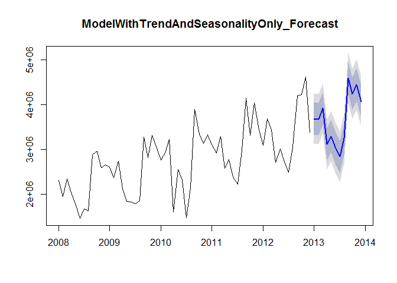

```r
# Add "newdata" to the 2013 indicator values for the forecast.
plot(ModelWithTrendAndSeasonalityOnly_Forecast, main="ModelWithTrendAndSeasonalityOnly_Forecast")
```

```r
ModelWithTrendAndSeasonalityOnly_Forecast
```

```
##          Point Forecast   Lo 80   Hi 80   Lo 95   Hi 95
## Jan 2013        3685709 3321691 4049727 3122318 4249100
## Feb 2013        3676775 3312757 4040793 3113384 4240166
## Mar 2013        3916745 3552727 4280763 3353354 4480136
## Apr 2013        3121815 2757797 3485833 2558424 3685206
## May 2013        3296229 2932211 3660247 2732838 3859620
## Jun 2013        3050908 2686890 3414926 2487517 3614299
## Jul 2013        2839188 2475170 3203206 2275797 3402579
## Aug 2013        3245143 2881125 3609161 2681752 3808534
## Sep 2013        4588614 4224596 4952632 4025223 5152005
## Oct 2013        4242616 3878598 4606634 3679225 4806007
## Nov 2013        4447389 4083371 4811407 3883998 5010780
## Dec 2013        4072720 3708702 4436737 3509329 4636110
```

```r
# Correlation of the forecasts and As Is data. As a comparison, the correlation of the As Is Data for 2013 with the Plan data.
cor(ModelWithTrendAndSeasonalityOnly_PointForecast, TotalAsIs_2013)
```

```
## [1] 0.9138049
```

```r
cor(TotalAsIs_2013, TotalPlan_2013)
```

```
## [1] 0.929769
```

```r
# A Comparison with linear regression also supports the result.
summary(ModelWithTrendAndSeasonalityOnly_Forecast_lm)
```

```
##
## Call:
## lm(formula = TotalAsIs_2013 ~ ModelWithTrendAndSeasonalityOnly_PointForecast,
##     data = TotalAsIs_2013)
##
## Residuals:
##     Min      1Q  Median      3Q     Max
## -516239 -216450   33683  123007  675607
##
## Coefficients:
##                                                  Estimate Std. Error
## (Intercept)                                    -8.142e+05  6.536e+05
## ModelWithTrendAndSeasonalityOnly_PointForecast  1.249e+00  1.755e-01
##                                                t value Pr(>|t|)
## (Intercept)                                     -1.246    0.241
## ModelWithTrendAndSeasonalityOnly_PointForecast   7.115 3.24e-05 ***
## ---
## Signif. codes:  0 '***' 0.001 '**' 0.01 '*' 0.05 '.' 0.1 ' ' 1
##
## Residual standard error: 337300 on 10 degrees of freedom
## Multiple R-squared:  0.835,  Adjusted R-squared:  0.8185
## F-statistic: 50.62 on 1 and 10 DF,  p-value: 3.238e-05
```

```r
summary(TotalAsIs_2013_lm)
```

```
##
## Call:
## lm(formula = TotalAsIs_2013 ~ TotalPlan_2013, data = TotalAsIs_2013)
##
## Residuals:
##     Min      1Q  Median      3Q     Max
## -441885 -227385  -43470  184761  466401
##
## Coefficients:
##                  Estimate Std. Error t value Pr(>|t|)
## (Intercept)    -8.972e+04  4.930e+05  -0.182    0.859
## TotalPlan_2013  1.053e+00  1.318e-01   7.987  1.2e-05 ***
## ---
## Signif. codes:  0 '***' 0.001 '**' 0.01 '*' 0.05 '.' 0.1 ' ' 1
##
## Residual standard error: 305700 on 10 degrees of freedom
## Multiple R-squared:  0.8645, Adjusted R-squared:  0.8509
## F-statistic: 63.78 on 1 and 10 DF,  p-value: 1.195e-05
```

### Interpretation of the forecasts

Below are the results of the forecasts with the new model  
AsIs Data for 2013 summary(TotalAsIs_2013_lm) Adjusted R²: 0.8509

### ModelWithInflationAndNationalHolidays

cor(ModelWithInflationAndNationalHolidays_PointForecast, TotalAsIs_2013)  
[1] 0.9598657  
cor(TotalAsIs_2013, TotalPlan_2013)  
[1] 0.929769  
Adjusted R²: 0.9135  
### ModelwithTrendAndSeasonalityOnly

cor(ModelWithTrendAndSeasonalityOnly_PointForecast, TotalAsIs_2013)  
[1] 0.9138049  
cor(TotalAsIs_2013, TotalPlan_2013)  
[1] 0.929769  
Adjusted R²: 0.8185  
The better model is ModelWithInflationAndNationalHolidays. It finally outperforms the plan data and provides explanatory potential.  
We will now use the ModelWithInflationAndNationalHolidays to forecast the year 2014